# Introduction

Session 1

Luis F. Gómez L.

luis.gomezl@unimilitar.edu.co

Distance Learning Faculty

26 January, 2026

# Please Read Me

- Check the message **Welcome greeting** published in Announcements forum.
- Dear student please edit your profile uploading a photo where your face is clearly visible.
- If you want to participate, please fill out the following survey: **Primer corte 30% > Learning Activities > Tu opinión sobre la economía colombiana**
- This presentation is based on (Cardenas, 2020, Chapter 1)
- **Purpose**
  - Identify the main characteristics of the Colombian economy, especially those that differentiate it from other economies

# The big picture and connecting ideas

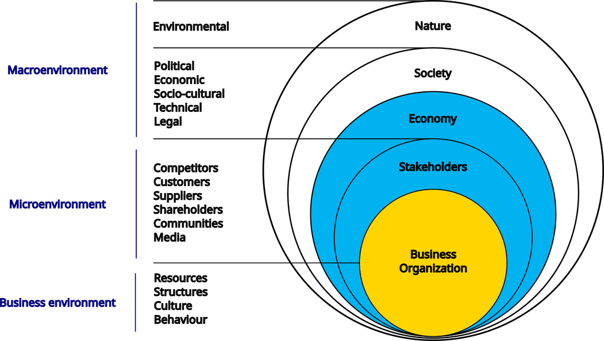

Figure 1: Macro, micro and organizational level business (Saukkonen & Kirjavainen, 2020)

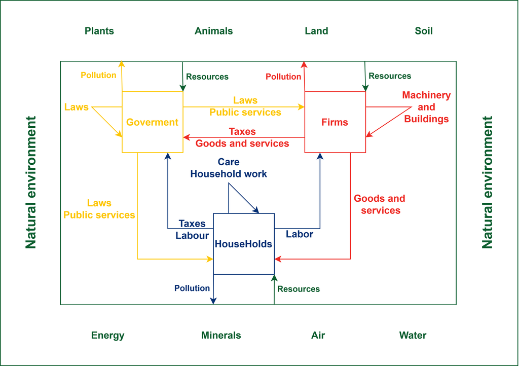

Figure 2: A model of the economy: flows of resources (Team, 2023, Chapter 1, sec. 1.13)

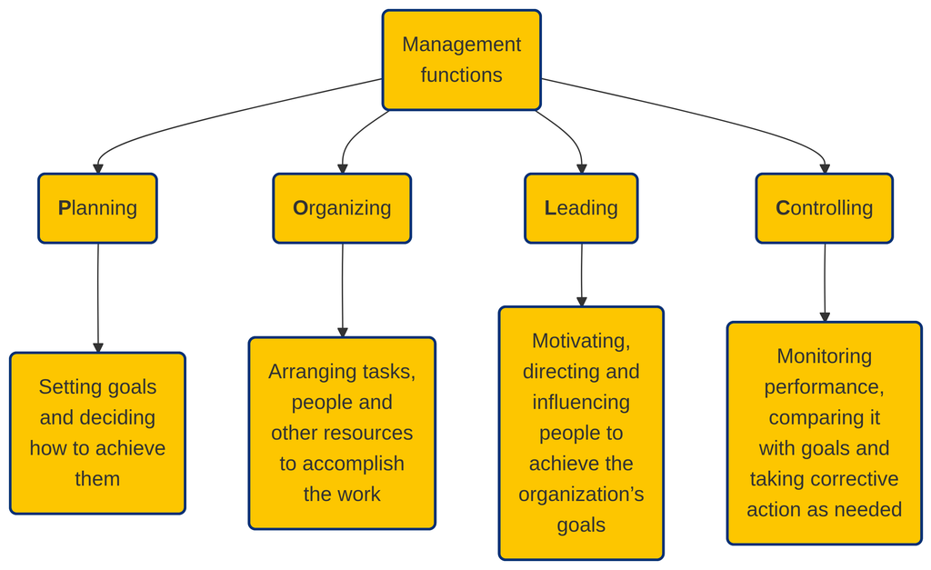

Figure 3: POLC framework (Kinicki & Soignet, 2022, pp. 8–10)

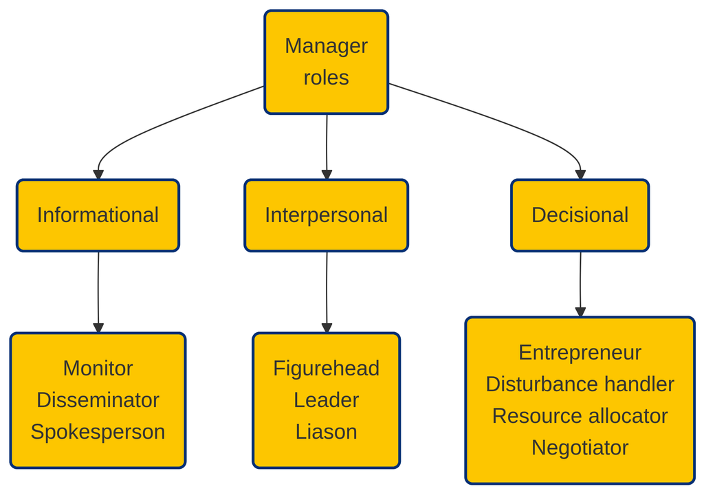

Figure 4: The roles managers play (Featured, 2019, Chapter 2, sec. 1.2)

# People

[interactive chart not shown]

Figure 5: Population pyramids in Colombia[^1]

- Why the behavior of population is important?
  - *“Demographic change must be taken into account to redesign human development and comprehensive well-being policies within the framework of longer lifespans.”* (DNP, 2022, p. 36)

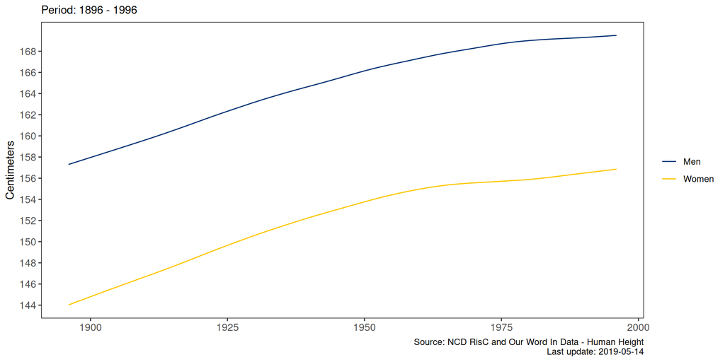

Figure 6: Average adult height by year of birth in Colombia (Roser et al., 2024)

- Why height is important?
  - *“Height provides a measure of biological quality of life, one of the dimensions of overall quality of life.”* (Meisel & Vega, 2007, p. 37)
  - *“Poor nutrition and illness in childhood limit human growth. As a consequence, the average height of a population is strongly correlated with living standards in a population.”* (Roser et al., 2024)

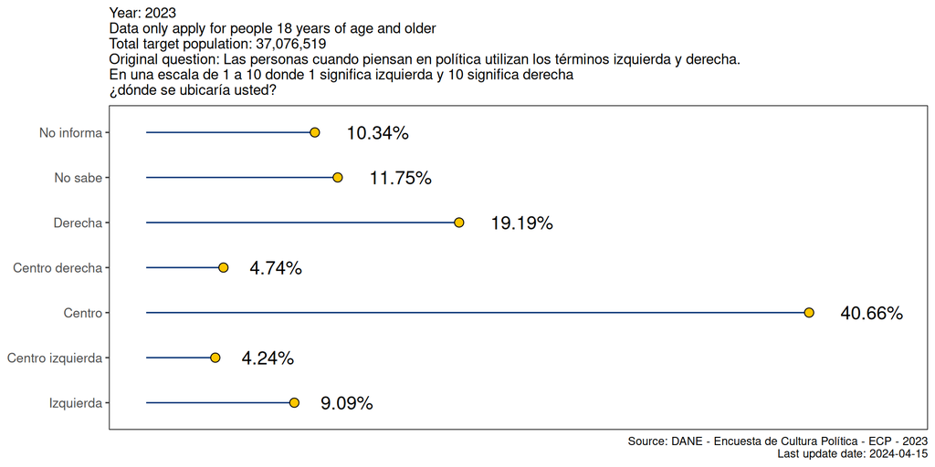

Figure 7: Ideological position in Colombia

- Why political preferences matter in an economic context?
  - In a democracy political preferences matter because the representatives that we choose determine some economic outcomes. For example:
    - Level of taxation and spending
    - Level of regulation like in the case of the environment or the labor market
    - Trade policy in relation to more or less free trade or proteccionism
- If you want to learn more about people in Colombia check out:
  - Primer corte 30% > Learning Resources > Links of interest > Así se ve Colombia en 100 personas - La Silla Vacía

# Households

- **ingtotug**: *“Ingreso total de la unidad de gasto **antes** de imputación de arriendo a propietarios y usufructuarios”* (DNP & DANE, 2012, pp. 16–17)
  - *Ingreso monetario primera actividad (IMPA)*
  - *Ingreso en especie (IE)*
  - *Ingreso segunda actividad (ISA)*
  - *Ingreso monetario de desocupados e inactivos (IMDI)*
  - *Ingresos por otras fuentes (IOF)*
- **ingtotugarr**: “Ingreso total de la unidad de gasto con imputación de arriendo a propietarios y usufructuarios” (DNP & DANE, 2012, pp. 24–26)
  - Modulo B Datos de la Vivienda: 11. Si tuviera que pagar arriendo por esta vivienda, ¿cuánto estima que tendría que pagar mensualmente? (DANE, 2019, p. 2)

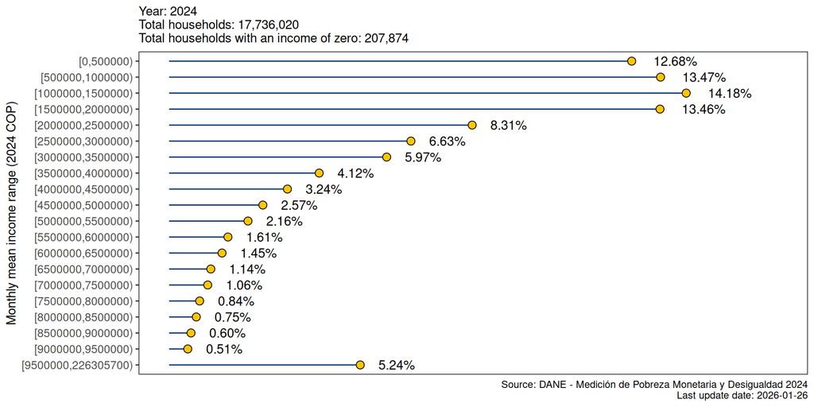

Figure 8: Household income distribution in Colombia

- If you want to explore more about this topic using data from the year 2023 check out[^2]:
  - https://www.ofiscal.org/ > Interactúa > Calcule dónde se ubica su hogar según su ingreso
- If you want to explore more about this topic from around the world in a visual way check out[^3]:
  - [See how the rest of the world lives, organized by income](https://youtu.be/u4L130DkdOw) (Configure spanish subtitles in the setting options)
  - https://www.gapminder.org > Resources > See the reality behind the data
    - https://www.gapminder.org/dollar-street

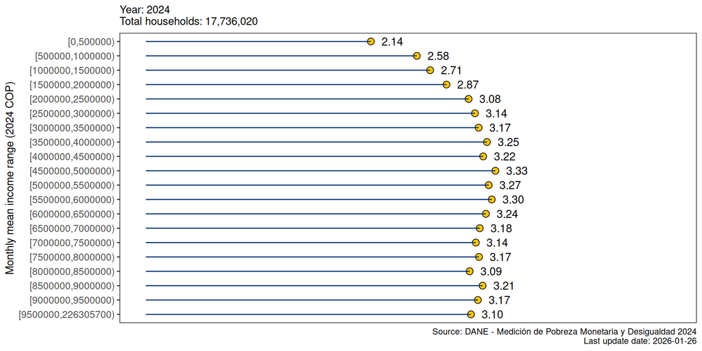

Figure 9: Mean individuals per household by income range in Colombia

- Housing (vivienda) ownership status[^4]
  - *Propia, totalmente pagada*
  - *Propia, la están pagando*
  - *En arriendo o subarriendo*
  - *En usufructo*
  - *Posesión sin título*
  - *Propiedad colectiva*
  - *Otra*
- The concept of housing (vivienda) is different from a household (hogar)
  - Zero or more households can live in a housing (vivienda)
  - For a detail definition of a househould check out (United Nations, 2017, pp. 38, 2.33)

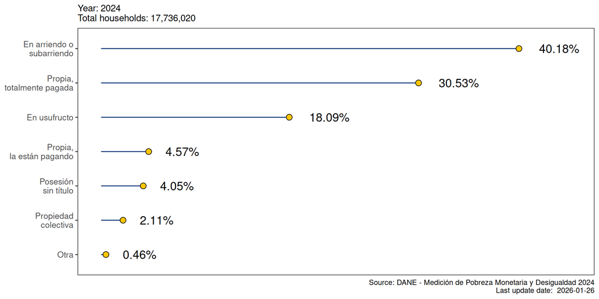

Figure 10: Housing ownership status of households in Colombia

# School education system

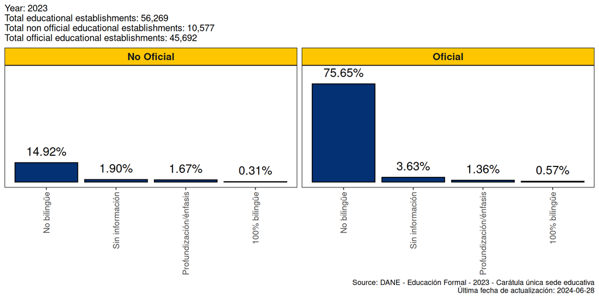

Figure 11: Bilingualism and educational establishments (preschool, elementary, middle and high school) in Colombia

- Why learn a foreign language?
  - The benefits of foreign language learning can be divided into 3 categories: intercultural understanding, economic benefits and cognitive (OECD, 2021, p. 10)
    - Intercultural understanding: by learning a foreign language you can understand other cultures and visions of the world (OECD, 2021, p. 11).
    - Economic: people who know more than one language are more likely to be employed and have better career opportunities (OECD, 2021, pp. 10–11).
    - Cognitive: students how learn a foreign language or more creative and better and solving complex problems (OECD, 2021, p. 11).

# Acknowledgments

- To my family that supports me
- To the taxpayers of Colombia and the [**UMNG students**](https://www.umng.edu.co/estudiante) who pay my salary
- To the [**Business Science**](https://www.business-science.io/) and [**R4DS Online Learning**](https://www.rfordatasci.com/) communities where I learn [**R**](https://www.r-project.org/about.html) and [**$\pi$-thon**](https://www.python.org/about/)
- To the [**R Core Team**](https://www.r-project.org/contributors.html), the creators of [**RStudio IDE**](https://posit.co/download/rstudio-desktop/), [**Positron**](https://positron.posit.co/), [**Quarto**](https://quarto.org/) and the authors and maintainers of the packages [**tidyverse**](https://CRAN.R-project.org/package=tidyverse), [**readxl**](https://CRAN.R-project.org/package=readxl), [**janitor**](https://CRAN.R-project.org/package=janitor), [**scales**](https://CRAN.R-project.org/package=scales), [**plotly**](https://CRAN.R-project.org/package=plotly) and [**tinytex**](https://CRAN.R-project.org/package=tinytex) for allowing me to access these tools without paying for a license

# References

Cardenas, M. (2020). *Introducción a la Economía Colombiana* (4th ed.). Alfaomega.

DANE. (2019). *Cuestionario I Trimestre Etapas 2001-2002-2003 - GEIH - Enero - Marzo - 2020*. https://microdatos.dane.gov.co/index.php/catalog/780/related-materials

DANE. (2022). *Manual de recolección y conceptos y básicos GEIH Etapas: 2210 - 2211 - 2212*. https://microdatos.dane.gov.co/index.php/catalog/771/related-materials

DNP. (2022). *VisiónColombia 2050: Discusión sobre el país del futuro*. Editorial Planeta Colombiana S. A. https://colaboracion.dnp.gov.co/CDT/Prensa/Publicaciones/Documento_vision_colombia_2050.pdf

DNP, & DANE. (2012). *Pobreza monetaria en colombia: Nueva metodología y cifras 2002-2010 resultados 2ª Fase de la MESEP*. http://microdatos.dane.gov.co/index.php/catalog/708/related_materials

Featured, O. (2019). *Principles of management* (1st ed.). OpenStax. https://openstax.org/details/books/principles-management

Kinicki, A., & Soignet, D. B. (2022). *Management: A practical introduction* (10th ed.). McGraw-Hill Education.

Meisel, A., & Vega, M. (2007). La estatura de los colombianos: Una ensayo de antropometría histórica, 1905-2003. In *Economía Colombiana del Siglo XX: Un análisis cuantitativo* (1st ed., pp. 35–79). Fondo de Cultura Económica.

OECD. (2021). *PISA 2025 Foreign Language Assessment Framework*. OECD Publishing.

Roser, M., Appel, C., & Ritchie, H. (2024). Human Height. In *Our World in Data*. https://ourworldindata.org/human-height

Saukkonen, N., & Kirjavainen, J. (2020). Business Environment: Emerging External and Internal Pressures for Sustainable Production. In W. Leal Filho, A. M. Azul, L. Brandli, P. G. Özuyar, & T. Wall (Eds.), *Responsible Consumption and Production* (pp. 37–48). Springer International Publishing. https://doi.org/10.1007/978-3-319-95726-5_1

Team, T. C. E. (2023). *The Economy 2.0: Microeconomics* (2nd ed.). https://core-econ.org/the-economy/

United Nations. (2017). *Principles and Recommendations for Population and Housing Censuses, Revision 3*. UN. https://doi.org/10.18356/bb3ea73e-en

## Footnotes

[^1]: Update: 2025-07-18
[^2]: Observatorio Fiscal de la Pontifica Universidad Javeriana
[^3]: Dollar Street
[^4]: For a detail definition of these categories checkout (DANE, 2022, p. 35)